# Final Project: R Reference

## Graphical Data Exploration

### plot() required arguments

Scatterplot:

Using the ginkgo data, create a scatterplot of max leaf depth (x) and max leaf width (y)

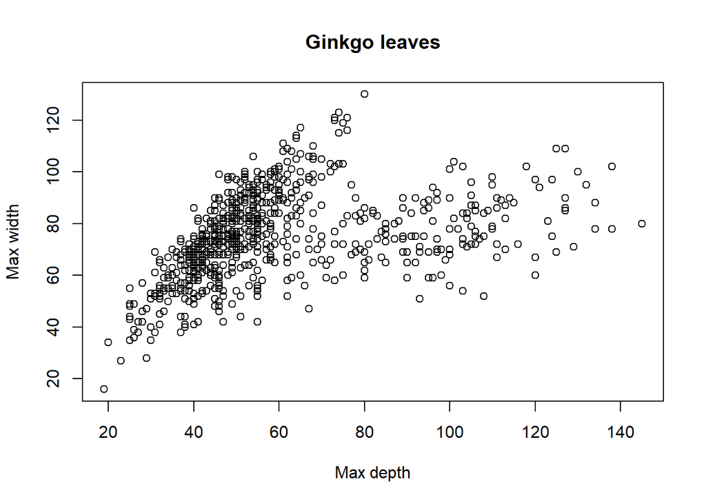

```r
plot(x = ginkgo$max_depth, y = ginkgo$max_width,
     xlab = "Max depth", ylab = "Max width", main = "Ginkgo leaves")
```

Plot using all arguments:

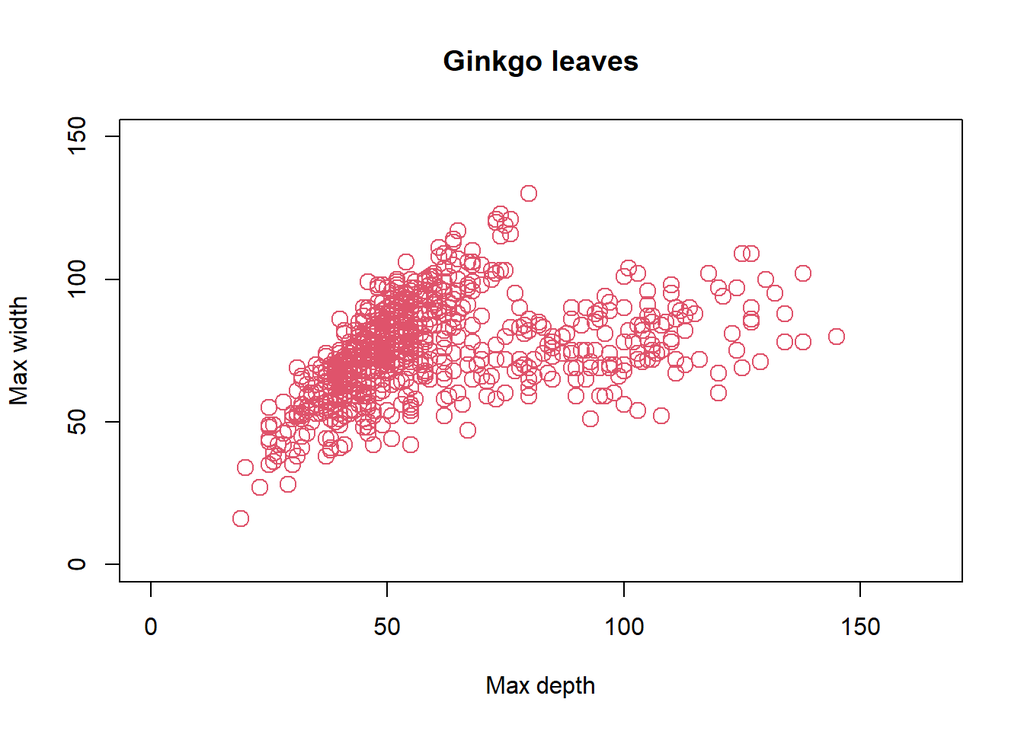

```r
plot(x = ginkgo$max_depth, y = ginkgo$max_width,
     xlab = "Max depth", ylab = "Max width", main = "Ginkgo leaves", col = "2", pch = 21, cex = 1.5, xlim = c(0, max(ginkgo$max_depth)+20), ylim = c(0, max(ginkgo$max_width)+20))
```

potential arguments to include:

- col = col = In R, the color black is denoted by col = 1 in most plotting functions, red is denoted by col = 2 , and green is denoted by col = 3 . So if you’re plotting multiple groups of things, it’s natural to plot them using colors 1, 2, and 3
- pch = pch = The default R plot pch symbol is 1, which is an empty circle. You can change this to pch = 19 (solid circle) or to pch = 21 (filled circle). To change the color and the size of points, use the following arguments: col : color (hexadecimal color code or color name)
- cex = cex = number indicating the amount by which plotting text and symbols should be scaled relative to the default. 1=default, 1.5 is 50% larger, 0.5 is 50% smaller, etc
- main = main = used to create a title Example: main = “Title of Graph”
- xlab = Example: main = “Title of Graph” xlab = used to label the x axis
- ylab = ylab = used to label the y axis
- xlim = xlim = used to set limits of the x axis. Ex: c(0, max(ginkgo$max_depth)+20)
- ylim = ylim = used to set limits of the y axis

### hist()

hist(): Create a histogram of penguin flipper lengths. Required arguments: breaks = It shows the breaks, which are the cutoff points for the bins. It shows the counts, intensity/density for each bin (same thing but two different names for R version compatibility), the midpoints of each bin, and then the name of the variable, whether the bins are equidistant, and the class of the object.

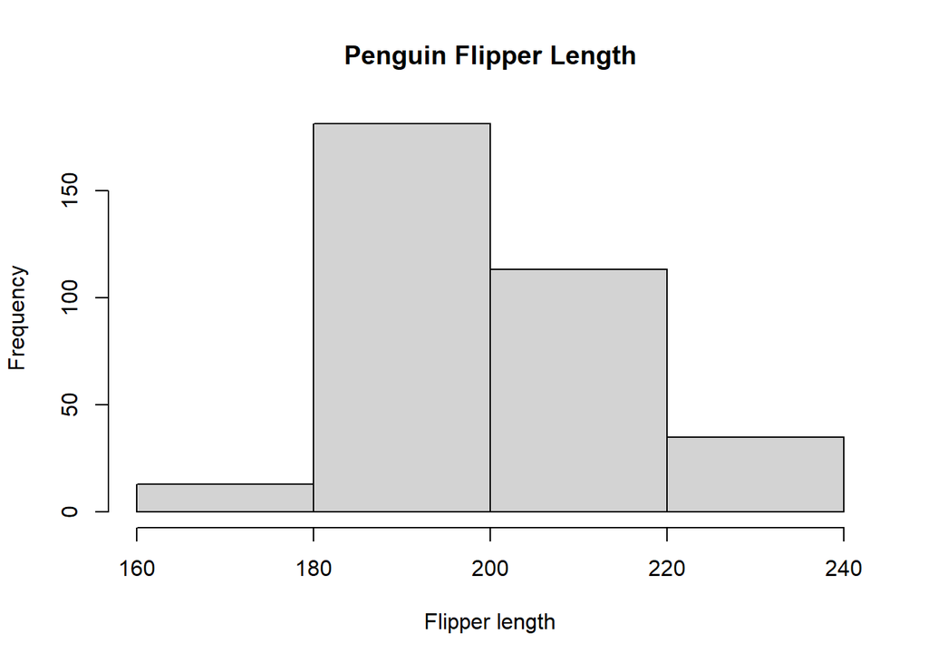

```r
hist(penguins$flipper_length_mm, xlab = "Flipper length", main = "Penguin Flipper Length", breaks = 4)
```

### boxplot()

Boxplot() Your must include two examples using the ginkgo data: a simple boxplot of ginkgo petiole lengths

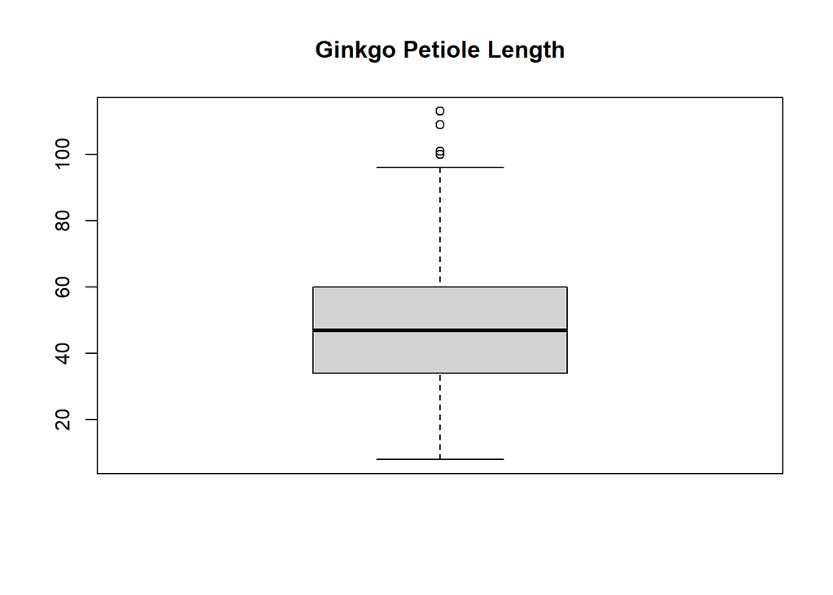

```r
boxplot(ginkgo$petiole_length, main = "Ginkgo Petiole Length")
```

conditional boxplot of one of the continuous variables conditioned on the seeds_present column.

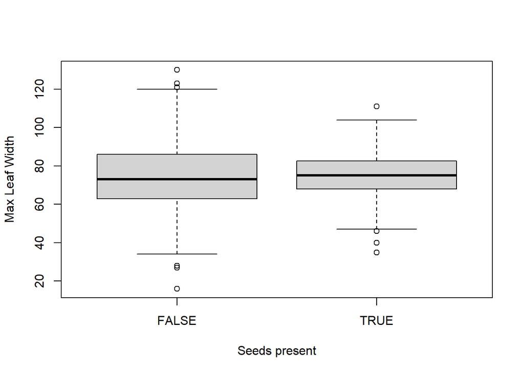

```r
boxplot(data = ginkgo, max_width ~ seeds_present, "Max width by Seeds present", xlab = "Seeds present", ylab = "Max Leaf Width")
```

```r
par(mfrow = c(2,2))
```

## Distribution Functions

This page has a helpful summary of what each function does: https://www.stat.umn.edu/geyer/old/5101/rlook.html

This is the in class assignment and has some useful information as well https://michaelfrancenelson.github.io/environmental_data/assignments/in_class_probabilities_2_functions_calculations.html

dnorm, pnorm, qnorm and rnorm all pull numbers from a normal distribution.

dnorm calculates the probability density (or mass) of a single event based on a normally distributed population, for example the probability of observing a sample mean 4.3cm for penguin flipper length.

Pnorm can be used to calculate the probability of observing values on above or below a critical value when calculating a confidence interval.

Density, distribution function, quantile function and random generation for the normal distribution with mean equal to mean and standard deviation equal to sd.

### dnorm()

dnorm() dnorm() calculates the probability density function for a given value in a normal distribution. It finds the value of y (height of the curve) for a given value of x. The mean and standard deviation of the distribution must be provided.

```r
dnorm(1.5, mean = 0, sd = 1)
```

```
## [1] 0.1295176
```

### pnorm()

pnorm() pnorm() calculates the cumulative distribution function for a given value in a normal distribution. It finds the probability of the given value OR LESS occurring. The mean and standard deviation of the distribution must be provided.

```r
pnorm(1.5, mean = 0, sd = 1)
```

```
## [1] 0.9331928
```

To find the probability of the given value OR MORE, use the “lower.tail = FALSE” option.

```r
pnorm(1.5, mean = 0, sd = 1, lower.tail = FALSE)
```

```
## [1] 0.0668072
```

### dbinom()

The _binom functions work to generate the binomial distribution with the density, distribution, and quantile functions as well as with random number generation using parameters size and prob. This is conventionally interpreted as the number of ‘successes’ in size trials.

### pbinom()

pbinom(): the cumulative mass function

### qbinom()

qbinom(): the quantile function

### Arguments:

x, q : vector of quantiles.

p : vector of probabilities.

n : number of observations. If length(n) > 1, the length is taken to be the number required.

size : number of trials (zero or more).

prob : probability of success on each trial. log, log.p  
logical; if TRUE, probabilities p are given as log(p). lower.tail  
logical; if TRUE (default), probabilities are P[X ≤ x], otherwise, P[X > x]. …